# Running Jupyter at ES infrastructure

```python
!cowsay open the terminal in your workstation
```

```
 _______________________________________
< open the terminal in your workstation >
 ---------------------------------------
        \   ^__^
         \  (oo)\_______
            (__)\       )\/\
                ||----w |
                ||     ||
```

# SSH to your workstation

*Note: If you are sitting in front of your workstation, this instructions are not needed*

```
$ ssh -X -L 8888:localhost:8888 bscearthXXX
```

The `-L 8888:localhost:8888` instructs `ssh`:

1. to forward (i.e. *tunnel*) your laptop TCP port # 8888
2. to your workstation's local TCP port # 8888 (`localhost:8888`). **This will be important later**

The `-X` forward the remote X11 display actions to your laptop. *Note: This requires a X11 server running on your laptop*

# Load the IPython module

```
user@bscearthXXX:~> module load IPython/6.4.0-foss-2015a-Python-3.7.3
```

If you plan to use other related modules or libraries in your Jupyter Notebook or IPython Console, you need to load them.

For example Pandas and/or Matplotlib:

```
user@bscearthXXX:~> module load pandas-compat/0.1.1-foss-2015a-Python-3.7.3
user@bscearthXXX:~> module load matplotlib/3.1.1-foss-2015a-Python-3.7.3
```

# Using other kernels: R

To install the R kernel:

```
user@bscearthXXX:~> module load IPython/6.4.0-foss-2015a-Python-3.7.3
user@bscearthXXX:~> jupyter-kernelspec install /shared/earth/software/IPython/6.4.0-foss-2015a-Python-3.7.3/share/jupyter/kernels/ir/ --user
```

*Note: This is only needed once*

Load the R module:

```
user@bscearthXXX:~> module load R/3.4.3-foss-2015a-bare
```

# Start the IPython console

```
user@bscearthXXX:~> ipython
Python 3.7.3 (default, Jun 28 2019, 15:47:16)
Type 'copyright', 'credits' or 'license' for more information
IPython 6.4.0 -- An enhanced Interactive Python. Type '?' for help.

In [1]: import from matplotlib.pyplot as plt
In [2]: plt.plot([0,1],[0,1])
```

This should be the result (*Note: appareance depends on your configuration)*

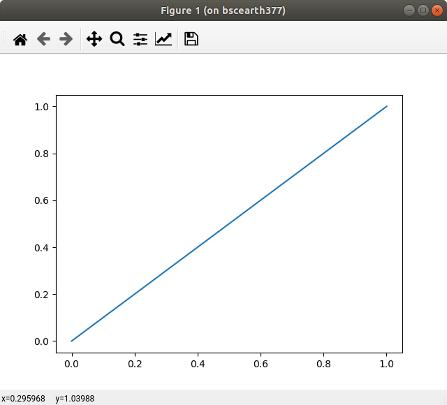

# Start the Jupyter Notebook App

```
user@bscearthXXX:~> jupyter notebook
```

Wait ... but this command will open automatically the browser ... and this OK if you are sitting in front of your workstation.

But if you are accessing remotely to your workstation, then you need to use the browser on your laptop.

The X can be tunneled/forwarded by SSH but the network's high latency makes this user experience a *pain in the a**!!!*

Do you remenber your *forwarded* port on the SSH connection slide? Here that is where it become useful: `-L 8888:localhost:8888`

# Start the Jupyter Notebook App: no browser

First, tell Jupyter Notebook App don't launch browser automatically:

```
user@bscearthXXX:~> jupyter notebook --no-browser
[I 20:04:07.659 NotebookApp] Serving notebooks from local directory: /home/Earth/user
[I 20:04:07.659 NotebookApp] 0 active kernels
[I 20:04:07.659 NotebookApp] The Jupyter Notebook is running at:
[I 20:04:07.659 NotebookApp] http://localhost:8888/?token=05f7f9704aea3a222bafef8bdb4d6bfe1ab0618af4d7f420
[I 20:04:07.659 NotebookApp] Use Control-C to stop this server and shut down all kernels (twice to skip confirmation).
[C 20:04:07.659 NotebookApp]

    Copy/paste this URL into your browser when you connect for the first time,
    to login with a token:
        http://localhost:8888/?token=05f7f9704aea3a222bafef8bdb4d6bfe1ab0618af4d7f420
```

Take special attention to the link been reported by the Jypyter Notebook App.

# Access to the Jupyter Notebook Dashboard

Open your browser and paste the reported link into the address bar:

[figure not shown]

# List running Jupyter Notebook Apps

You can recover the list of running notebooks and their connection links by the command:

```
user@bscearthXXX:~> jupyter notebook list
Currently running servers:
http://localhost:8888/?token=05f7f9704aea3a222bafef8bdb4d6bfe1ab0618af4d7f420 :: /home/Earth/user
```

# Jupyter Notebooks for Beginners

https://www.dataquest.io/blog/jupyter-notebook-tutorial/

# Jupyter Notebooks Manual

https://jupyter.brynmawr.edu/services/public/dblank/Jupyter%20Notebook%20Users%20Manual.ipynb

# Jupyter Notebooks Best Practices

Jupyter Notebook Best Practices for Data Science: https://www.svds.com/tbt-jupyter-notebook-best-practices-data-science/?utm_source=kdnuggets&utm_medium=referral

# Interesting Jupyter Notebooks

https://github.com/jupyter/jupyter/wiki/A-gallery-of-interesting-Jupyter-Notebooks